# Performance Analyses

We’ll start by doing some basic performance analyses on disconnect data, followed by doing the same analyses on green data. For each, I’ll analyze the interaction between RSI and transition on response time and error rates.

# Experiment 1 Performance Data

## Response Time Data

Let’s first check out the subject-wise means. *Note: all RT data has been trimmed at +/- 2 SDs on subject-wise means*

Load libraries and data:

```r
library(data.table)
library(dplyr)
library(ggplot2)
library(ez)
rt_data <- fread('../experiment_one/data/disconnect_rt.csv')
error_data <- fread('../experiment_one/data/disconnect_errors.csv')
current_data <- fread('../experiment_one/data/disconnect.csv')
rt_data
```

| subject | block | leftpoints | rightpoints | responselocation | rsi | rt | blocktime | transcode | stimrep | current_pv | other_pv | difference | subject_error |
| --- | --- | --- | --- | --- | --- | --- | --- | --- | --- | --- | --- | --- | --- |
| 1 | 1 | 6 | 3 | left | 1100 | 2737 | 182.620 | 0 | 0 | 6 | 3 | -3 | 0.02258469 |
| 1 | 1 | 8 | 10 | right | 200 | 1443 | 182.620 | 1 | 1 | 8 | 10 | 2 | 0.02258469 |
| 1 | 1 | 4 | 10 | right | 200 | 826 | 182.620 | 0 | 1 | 10 | 4 | -6 | 0.02258469 |
| 1 | 1 | 10 | 1 | left | 1100 | 597 | 182.620 | 1 | 1 | 1 | 10 | 9 | 0.02258469 |
| 1 | 1 | 6 | 10 | right | 200 | 1127 | 182.620 | 1 | 0 | 6 | 10 | 4 | 0.02258469 |
| 1 | 1 | 3 | 4 | right | 200 | 859 | 182.620 | 0 | 0 | 4 | 3 | -1 | 0.02258469 |
| 1 | 1 | 8 | 7 | left | 1100 | 426 | 182.620 | 1 | 0 | 7 | 8 | 1 | 0.02258469 |
| 1 | 1 | 4 | 5 | right | 1100 | 811 | 182.620 | 1 | 0 | 4 | 5 | 1 | 0.02258469 |
| 1 | 1 | 8 | 6 | left | 1100 | 1516 | 182.620 | 1 | 0 | 6 | 8 | 2 | 0.02258469 |
| 1 | 1 | 10 | 3 | left | 200 | 1440 | 182.620 | 0 | 0 | 10 | 3 | -7 | 0.02258469 |

[output cut: 990 more lines]

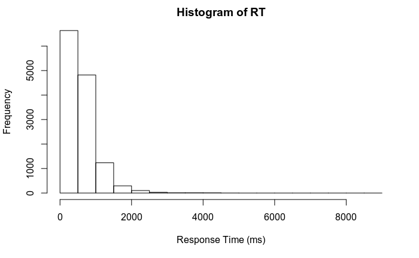

```r
hist(rt_data$rt, main = 'Histogram of RT', xlab = 'Response Time (ms)')
```

```r
paste('Mean RT:', mean(rt_data$rt), 'Min RT:', min(rt_data$rt), 'Max RT:', max(rt_data$rt))
```

```
[1] "Mean RT: 629.278086255419 Min RT: 133 Max RT: 8757"
```

Looking at the subject-wise means for RSI X Transition -> RT

| subject | rsi | transcode | rt |
| --- | --- | --- | --- |
| 1 | 200 | 0 | 900.2606 |
| 1 | 200 | 1 | 1333.3289 |
| 1 | 1100 | 0 | 685.6465 |
| 1 | 1100 | 1 | 896.6644 |
| 2 | 200 | 0 | 632.4967 |
| 2 | 200 | 1 | 1013.2519 |
| 2 | 1100 | 0 | 488.3977 |
| 2 | 1100 | 1 | 699.7279 |
| 3 | 200 | 0 | 746.5858 |
| 3 | 200 | 1 | 1026.6544 |

[output cut: 64 more lines]

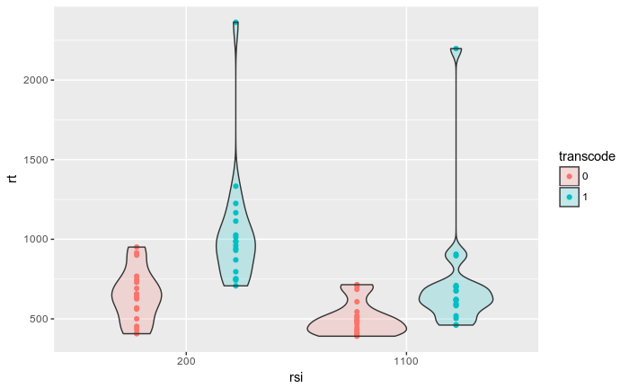

```r
rt_data$transcode <- as.factor(rt_data$transcode)
rt_data$rsi <- as.factor(rt_data$rsi)
rt_data %>%
  group_by(subject, rsi, transcode) %>%
  summarize(rt = mean(rt)) %>%
  print() %>%
  ggplot(aes(x = rsi, y = rt)) + geom_point(aes(group = transcode, color = transcode), position = position_dodge(width = 0.9)) +
    geom_violin(aes(fill = transcode),alpha = .2)
```

According to the plot, it looks as though there are a couple outlier points, but I double checked and the data going into these were indeed trimmed at +/- 2 SDs on subject-wise means.

Let’s make sure all subjects have data in all cells of the design:

```r
rt_data %>%
  group_by(subject, rsi, transcode) %>%
  summarize(rt = mean(rt)) %>%
  group_by(subject) %>%
  summarize(n())
```

| subject | n() |
| --- | --- |
| 1 | 4 |
| 2 | 4 |
| 3 | 4 |
| 4 | 2 |
| 5 | 4 |
| 6 | 4 |
| 7 | 4 |
| 8 | 4 |
| 9 | 4 |
| 10 | 4 |

[output cut: 9 more lines]

```r
NA
```

We can see that subject 4 and 17 have two missing cells, so we’ll drop these subjects from the analysis

```r
rt_data <- rt_data %>%
  filter(subject != 4 & subject != 17) %>%
  data.table()
```

Let’s run an ANOVA and plot the results

```r
N <- rt_data %>%
  group_by(subject) %>%
  summarize(n()) %>%
  nrow()
model1 <- rt_data %>%
  group_by(subject, rsi, transcode) %>%
  summarize(rt = mean(rt)) %>%
  ezANOVA(wid = subject, within = .(rsi, transcode), dv = rt, type = 2, detailed = T)
```

```
Converting "subject" to factor for ANOVA.
```

```r
cbind(model1$ANOVA, n2p = model1$ANOVA$SSn / (model1$ANOVA$SSn + model1$ANOVA$SSd))
```

|  | Effect | DFn | DFd | SSn | SSd | F | p | p<.05 | ges | n2p |
| --- | --- | --- | --- | --- | --- | --- | --- | --- | --- | --- |
| 1 | (Intercept) | 1 | 16 | 32033725.8 | 1011292.32 | 506.81648 | 1.531986e-13 | * | 0.95963529 | 0.9693965 |
| 2 | rsi | 1 | 16 | 980567.8 | 81667.82 | 192.10853 | 2.483829e-10 | * | 0.42120826 | 0.9231170 |
| 3 | transcode | 1 | 16 | 852887.6 | 226510.50 | 60.24534 | 8.190040e-07 | * | 0.38762193 | 0.7901511 |
| 4 | rsi:transcode | 1 | 16 | 112385.3 | 27949.65 | 64.33583 | 5.360248e-07 | * | 0.07698646 | 0.8008361 |

```r
dodge <- position_dodge(width = 0.9)
rt_data %>%
  group_by(subject, rsi, transcode) %>%
  summarize(rt = mean(rt)) %>%
  group_by(rsi) %>%
  summarize(r_time = mean(rt), se = sd(rt) / sqrt(N))
```

| rsi | r_time | se |
| --- | --- | --- |
| 200 | 806.4395 | 55.66054 |
| 1100 | 566.2720 | 32.00550 |

```r
rt_data %>%
  group_by(subject, transcode, rsi) %>%
  summarize(rt = mean(rt)) %>%
  group_by(transcode) %>%
  summarize(r_time = mean(rt), se = sd(rt) / sqrt(N))
```

| transcode | r_time | se |
| --- | --- | --- |
| 0 | 574.3626 | 37.41764 |
| 1 | 798.3489 | 54.31355 |

| rsi | transcode | r_time | se |
| --- | --- | --- | --- |
| 200 | 0 | 653.7927 | 39.63144 |
| 200 | 1 | 959.0864 | 43.66393 |
| 1100 | 0 | 494.9325 | 22.98634 |
| 1100 | 1 | 637.6114 | 30.79269 |

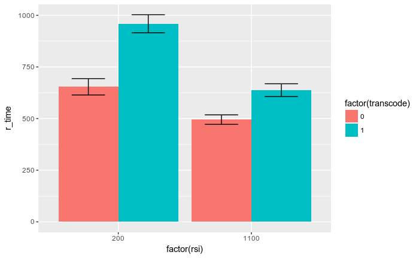

```r
rt_data %>%
  group_by(subject, rsi, transcode) %>%
  summarize(rt = mean(rt)) %>%
  group_by(rsi, transcode) %>%
  summarize(r_time = mean(rt), se = sd(rt) / sqrt(N)) %>%
  print() %>%
  ggplot(aes(x = factor(rsi), y = r_time, group = factor(transcode))) + geom_bar(aes(fill = factor(transcode)), stat = 'identity', position = dodge) +
    geom_errorbar(aes(ymax = se + r_time, ymin = r_time - se, group = factor(transcode)), position = dodge, width = 0.5)
```

It looks like we’re seeing a signifant reduction in switch cost at longer RSIs, consistent with the literature.

To follow up on the interaction, we’ll look at the simple effect of transition within both long and short RSIs:

```r
# save the mean square and SSerror error for the interaction term in the omnibus model
omnibus_mse <- model1$ANOVA[4,'SSd'] / model1$ANOVA[4,'DFd']
ssd <- model1$ANOVA[4,'SSd']
# run follow-up models on long and short RSIs
longRSI_model <- ezANOVA(data = rt_data[rsi == '1100'], wid = subject, within = transcode, dv = rt, type = 2, detailed = T)
```

```
Converting "subject" to factor for ANOVA.Collapsing data to cell means. *IF* the requested effects are a subset of the full design, you must use the "within_full" argument, else results may be inaccurate.
```

```r
shortRSI_model <- ezANOVA(data = rt_data[rsi == '200'], wid = subject, within = transcode, dv = rt, type = 2, detailed = T)
```

```
Converting "subject" to factor for ANOVA.Collapsing data to cell means. *IF* the requested effects are a subset of the full design, you must use the "within_full" argument, else results may be inaccurate.
```

```r
# save mean square numerator (in this case it's the same thing as SSn, because DFn = 1)
longRSI_msn <- longRSI_model$ANOVA[2, 'SSn']
shortRSI_msn <- shortRSI_model$ANOVA[2, 'SSn']
#effect size
longRSI_n2p <- longRSI_msn / (longRSI_msn + ssd)
shortRSI_n2p <- shortRSI_msn / (shortRSI_msn + ssd)
#F statistic
longRSI_f <- longRSI_msn / omnibus_mse
shortRSI_f <- shortRSI_msn / omnibus_mse
# degress of freedom
df1 <- 1 ## same for both, because only two levels for both factors
df2 <- model1$ANOVA[2,'DFd'] #degrees of freedom error for the interaction term in omnibus analysis
# p values
longRSI_p <- pf(longRSI_f, df1, df2, lower.tail = F)
shortRSI_p <- pf(shortRSI_f, df1, df2, lower.tail = F)
## report the final effects
print('Simple effect of transition for long RSI')
```

```
[1] "Simple effect of transition for long RSI"
```

```r
paste("F(",df1,", ",df2, ") = ", round(longRSI_f, digits =2), ", p = ", round(longRSI_p, digits = 5), ', np2 = ', round(longRSI_n2p, digits = 2), sep='')
```

```
[1] "F(1, 16) = 99.06, p = 0, np2 = 0.86"
```

```r
print('Simple effect of transition for short RSI')
```

```
[1] "Simple effect of transition for short RSI"
```

```r
paste("F(",df1,", ",df2, ") = ", round(shortRSI_f, digits =2), ", p = ", round(shortRSI_p, digits = 5), ', np2 = ', round(shortRSI_n2p, digits = 2), sep='')
```

```
[1] "F(1, 16) = 453.52, p = 0, np2 = 0.97"
```

The effects are pretty huge across the board, but we can see that there is a greater switch cost at short RSIs rather than long RSIs.

## Error Data

I’m going to quickly run a similar ANOVA on the error data.

Error rates across conditions by subject:

```r
error_data %>%
  group_by(subject, transcode, rsi) %>%
  summarize(error = mean(error))
```

| subject | transcode | rsi | error |
| --- | --- | --- | --- |
| 1 | 0 | 200 | 0.04324324 |
| 1 | 0 | 1100 | 0.01895735 |
| 1 | 1 | 200 | 0.01764706 |
| 1 | 1 | 1100 | 0.01273885 |
| 2 | 0 | 200 | 0.16037736 |
| 2 | 0 | 1100 | 0.07407407 |
| 2 | 1 | 200 | 0.12631579 |
| 2 | 1 | 1100 | 0.12087912 |
| 3 | 0 | 200 | 0.07142857 |
| 3 | 0 | 1100 | 0.02475248 |

[output cut: 64 more lines]

| subject | rsi | transcode | error |
| --- | --- | --- | --- |
| 1 | 200 | 0 | 0.04324324 |
| 1 | 200 | 1 | 0.01764706 |
| 1 | 1100 | 0 | 0.01895735 |
| 1 | 1100 | 1 | 0.01273885 |
| 2 | 200 | 0 | 0.16037736 |
| 2 | 200 | 1 | 0.12631579 |
| 2 | 1100 | 0 | 0.07407407 |
| 2 | 1100 | 1 | 0.12087912 |
| 3 | 200 | 0 | 0.07142857 |
| 3 | 200 | 1 | 0.04117647 |

[output cut: 64 more lines]

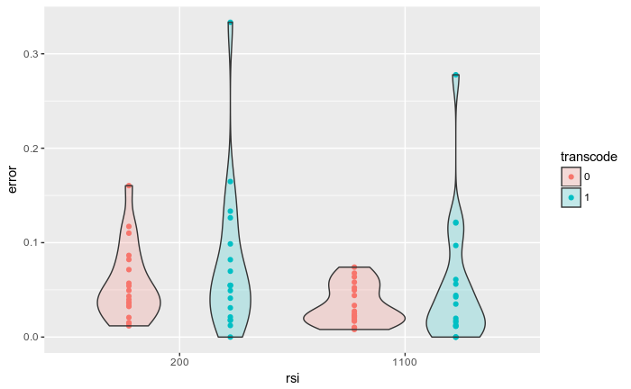

```r
error_data$transcode <- as.factor(error_data$transcode)
error_data$rsi <- as.factor(error_data$rsi)
error_data %>%
  group_by(subject, rsi, transcode) %>%
  summarize(error = mean(error)) %>%
  print() %>%
  ggplot(aes(x = rsi, y = error)) + geom_point(aes(group = transcode, color = transcode), position = position_dodge(width = 0.9)) +
    geom_violin(aes(fill = transcode),alpha = .2)
```

Checking that all subjects have data in all cells:

```r
error_data %>%
  group_by(subject, transcode, rsi) %>%
  summarize(error = mean(error)) %>%
  group_by(subject) %>%
  summarize(n())
```

| subject | n() |
| --- | --- |
| 1 | 4 |
| 2 | 4 |
| 3 | 4 |
| 4 | 2 |
| 5 | 4 |
| 6 | 4 |
| 7 | 4 |
| 8 | 4 |
| 9 | 4 |
| 10 | 4 |

[output cut: 9 more lines]

Yanking subject 4 and running the ANOVA and follow-ups if necessary:

```r
error_data <- error_data %>%
  filter(subject != 4)
model1 <- error_data %>%
  group_by(subject, rsi, transcode) %>%
  summarize(error = mean(error)) %>%
  ezANOVA(wid = subject, within = .(rsi, transcode), dv = error, type = 2, detailed = T)
```

```
Converting "subject" to factor for ANOVA.
```

```r
cbind(model1$ANOVA, n2p = model1$ANOVA$SSn / (model1$ANOVA$SSn + model1$ANOVA$SSd))
```

|  | Effect | DFn | DFd | SSn | SSd | F | p | p<.05 | ges | n2p |
| --- | --- | --- | --- | --- | --- | --- | --- | --- | --- | --- |
| 1 | (Intercept) | 1 | 17 | 2.200553e-01 | 0.11205132 | 33.385948849 | 2.227809e-05 | * | 5.007067e-01 | 0.6626043493 |
| 2 | rsi | 1 | 17 | 1.028961e-02 | 0.03094399 | 5.652905428 | 2.942924e-02 | * | 4.479126e-02 | 0.2495443883 |
| 3 | transcode | 1 | 17 | 5.602399e-03 | 0.03766667 | 2.528516408 | 1.302286e-01 |  | 2.489551e-02 | 0.1294781618 |
| 4 | rsi:transcode | 1 | 17 | 8.047750e-06 | 0.03877213 | 0.003528611 | 9.533245e-01 |  | 3.667368e-05 | 0.0002075223 |

```r
error_data %>%
  group_by(subject, rsi, transcode) %>%
  summarize(error = mean(error)) %>%
  group_by(rsi) %>%
  summarize(error = mean(error), se = sd(error) / sqrt(N))
```

| rsi | error | se |
| --- | --- | --- |
| 200 | 0.06723858 | NA |
| 1100 | 0.04332947 | NA |

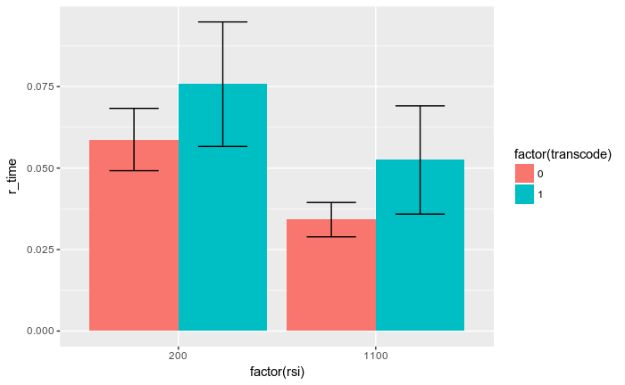

```r
dodge <- position_dodge(width = 0.9)
error_data %>%
  group_by(subject, rsi, transcode) %>%
  summarize(error = mean(error)) %>%
  group_by(rsi, transcode) %>%
  summarize(r_time = mean(error), se = sd(error) / sqrt(N)) %>%
  ggplot(aes(x = factor(rsi), y = r_time, group = factor(transcode))) + geom_bar(aes(fill = factor(transcode)), stat = 'identity', position = dodge) +
    geom_errorbar(aes(ymax = se + r_time, ymin = r_time - se, group = factor(transcode)), position = dodge, width = 0.5)
```

# Experiment 2 Performance Data

Just like Experiment 1, we’ll start with response time and move to error data.

## Response Times

```r
rt_data <- fread('../experiment_two/data/disconnect_green_rt.csv')
error_data <- fread('../experiment_two/data/disconnect_green_error.csv')
current_data <- fread('../experiment_two/data/disconnect_green.csv')
rt_data
```

| subject | block | rsi | rt | blocktime | transcode | stimrep | current_pv | other_pv | color | difference |
| --- | --- | --- | --- | --- | --- | --- | --- | --- | --- | --- |
| 1 | 1 | 1100 | 963 | 141.614 | 0 | 0 | 3 | 1 | black | -2 |
| 1 | 1 | 200 | 702 | 141.614 | 0 | 0 | 5 | 1 | green | -4 |
| 1 | 1 | 200 | 867 | 141.614 | 0 | 0 | 5 | 7 | black | 2 |
| 1 | 1 | 1100 | 1354 | 141.614 | 0 | 0 | 8 | 8 | black | 0 |
| 1 | 1 | 200 | 1056 | 141.614 | 1 | 0 | 2 | 7 | green | 5 |
| 1 | 1 | 1100 | 527 | 141.614 | 0 | 0 | 8 | 1 | light green | -7 |
| 1 | 1 | 200 | 900 | 141.614 | 0 | 1 | 9 | 6 | black | -3 |
| 1 | 1 | 200 | 697 | 141.614 | 0 | 1 | 3 | 3 | black | 0 |
| 1 | 1 | 1100 | 903 | 141.614 | 1 | 0 | 1 | 9 | light green | 8 |
| 1 | 1 | 1100 | 716 | 141.614 | 0 | 0 | 10 | 5 | green | -5 |

[output cut: 990 more lines]

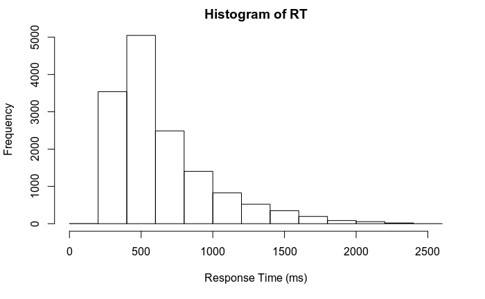

```r
hist(rt_data$rt, main = 'Histogram of RT', xlab = 'Response Time (ms)')
```

```r
paste('Mean RT:', mean(rt_data$rt), 'Min RT:', min(rt_data$rt), 'Max RT:', max(rt_data$rt))
```

```
[1] "Mean RT: 646.078166930434 Min RT: 68 Max RT: 2417"
```

Looking at the subject-wise means for RSI X Transition -> RT

| subject | rsi | transcode | rt |
| --- | --- | --- | --- |
| 1 | 200 | 0 | 980.7160 |
| 1 | 200 | 1 | 1153.5041 |
| 1 | 1100 | 0 | 896.1088 |
| 1 | 1100 | 1 | 994.4968 |
| 2 | 200 | 0 | 733.5108 |
| 2 | 200 | 1 | 845.5920 |
| 2 | 1100 | 0 | 580.8701 |
| 2 | 1100 | 1 | 704.2840 |
| 3 | 200 | 0 | 575.8820 |
| 3 | 200 | 1 | 933.1345 |

[output cut: 62 more lines]

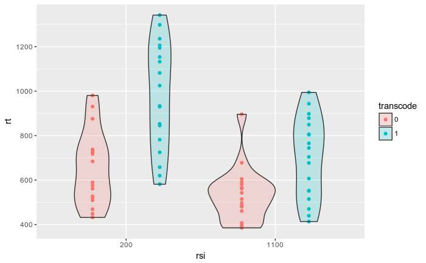

```r
rt_data$transcode <- as.factor(rt_data$transcode)
rt_data$rsi <- as.factor(rt_data$rsi)
rt_data %>%
  group_by(subject, rsi, transcode) %>%
  summarize(rt = mean(rt)) %>%
  print() %>%
  ggplot(aes(x = rsi, y = rt)) + geom_point(aes(group = transcode, color = transcode), position = position_dodge(width = 0.9)) +
    geom_violin(aes(fill = transcode),alpha = .2)
```

According to the plot, it looks as though there are a couple outlier points, but I double checked and the data going into these were indeed trimmed at +/- 2 SDs on subject-wise means.

Let’s make sure all subjects have data in all cells of the design:

```r
rt_data %>%
  group_by(subject, rsi, transcode) %>%
  summarize(rt = mean(rt)) %>%
  group_by(subject) %>%
  summarize(n())
```

| subject | n() |
| --- | --- |
| 1 | 4 |
| 2 | 4 |
| 3 | 4 |
| 4 | 4 |
| 5 | 4 |
| 6 | 4 |
| 7 | 4 |
| 8 | 4 |
| 9 | 4 |
| 10 | 4 |

[output cut: 8 more lines]

```r
NA
```

All subjects look good.

Let’s run an ANOVA and plot the results

```r
N <- rt_data %>%
  group_by(subject) %>%
  summarize(n()) %>%
  nrow()
model1 <- rt_data %>%
  group_by(subject, rsi, transcode) %>%
  summarize(rt = mean(rt)) %>%
  ezANOVA(wid = subject, within = .(rsi, transcode), dv = rt, type = 2, detailed = T)
```

```
Converting "subject" to factor for ANOVA.
```

```r
cbind(model1$ANOVA, n2p = model1$ANOVA$SSn / (model1$ANOVA$SSn + model1$ANOVA$SSd))
```

|  | Effect | DFn | DFd | SSn | SSd | F | p | p<.05 | ges | n2p |
| --- | --- | --- | --- | --- | --- | --- | --- | --- | --- | --- |
| 1 | (Intercept) | 1 | 17 | 36928731.1 | 1773231.35 | 354.03639 | 8.094703e-13 | * | 0.94212200 | 0.9541824 |
| 2 | rsi | 1 | 17 | 706330.3 | 116430.25 | 103.13140 | 1.234533e-08 | * | 0.23742218 | 0.8584883 |
| 3 | transcode | 1 | 17 | 1089786.6 | 336336.37 | 55.08287 | 9.980857e-07 | * | 0.32449061 | 0.7641603 |
| 4 | rsi:transcode | 1 | 17 | 111894.3 | 42668.86 | 44.58057 | 3.896448e-06 | * | 0.04700331 | 0.7239389 |

| rsi | transcode | r_time | se |
| --- | --- | --- | --- |
| 200 | 0 | 652.7658 | 38.81274 |
| 200 | 1 | 977.6659 | 57.04451 |
| 1100 | 0 | 533.5173 | 28.82033 |
| 1100 | 1 | 700.7298 | 42.69459 |

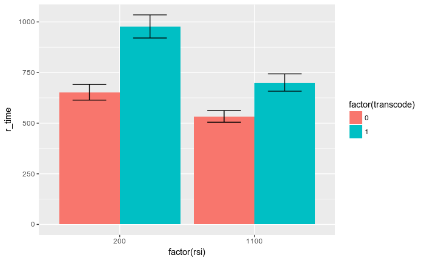

```r
dodge <- position_dodge(width = 0.9)
rt_data %>%
  group_by(subject, rsi, transcode) %>%
  summarize(rt = mean(rt)) %>%
  group_by(rsi, transcode) %>%
  summarize(r_time = mean(rt), se = sd(rt) / sqrt(N)) %>%
  print() %>%
  ggplot(aes(x = factor(rsi), y = r_time, group = factor(transcode))) + geom_bar(aes(fill = factor(transcode)), stat = 'identity', position = dodge) +
    geom_errorbar(aes(ymax = se + r_time, ymin = r_time - se, group = factor(transcode)), position = dodge, width = 0.5)
```

We’re seeing the same general effects as in Experiment 1, and (once again) the interaction is highly significant. Spitting out means and following up on the interaction:

```r
## print means for main effects
rt_data %>%
  group_by(subject, rsi) %>%
  summarize(rt = mean(rt)) %>%
  group_by(rsi) %>%
  summarize(r_time = mean(rt), se = sd(rt) / sqrt(N))
```

| rsi | r_time | se |
| --- | --- | --- |
| 200 | 732.8041 | 44.60328 |
| 1100 | 579.8018 | 32.73513 |

```r
rt_data %>%
  group_by(subject, transcode) %>%
  summarize(rt = mean(rt)) %>%
  group_by(transcode) %>%
  summarize(r_time = mean(rt), se = sd(rt) / sqrt(N))
```

| transcode | r_time | se |
| --- | --- | --- |
| 0 | 592.8643 | 32.85363 |
| 1 | 829.3015 | 48.98121 |

```r
# save the mean square and SSerror error for the interaction term in the omnibus model
omnibus_mse <- model1$ANOVA[4,'SSd'] / model1$ANOVA[4,'DFd']
ssd <- model1$ANOVA[4,'SSd']
# run follow-up models on long and short RSIs
longRSI_model <- ezANOVA(data = rt_data[rsi == '1100'], wid = subject, within = transcode, dv = rt, type = 2, detailed = T)
```

```
Converting "subject" to factor for ANOVA.Collapsing data to cell means. *IF* the requested effects are a subset of the full design, you must use the "within_full" argument, else results may be inaccurate.
```

```r
shortRSI_model <- ezANOVA(data = rt_data[rsi == '200'], wid = subject, within = transcode, dv = rt, type = 2, detailed = T)
```

```
Converting "subject" to factor for ANOVA.Collapsing data to cell means. *IF* the requested effects are a subset of the full design, you must use the "within_full" argument, else results may be inaccurate.
```

```r
# save mean square numerator (in this case it's the same thing as SSn, because DFn = 1)
longRSI_msn <- longRSI_model$ANOVA[2, 'SSn']
shortRSI_msn <- shortRSI_model$ANOVA[2, 'SSn']
#effect size
longRSI_n2p <- longRSI_msn / (longRSI_msn + ssd)
shortRSI_n2p <- shortRSI_msn / (shortRSI_msn + ssd)
#F statistic
longRSI_f <- longRSI_msn / omnibus_mse
shortRSI_f <- shortRSI_msn / omnibus_mse
# degress of freedom
df1 <- 1 ## same for both, because only two levels for both factors
df2 <- model1$ANOVA[2,'DFd'] #degrees of freedom error for the interaction term in omnibus analysis
# p values
longRSI_p <- pf(longRSI_f, df1, df2, lower.tail = F)
shortRSI_p <- pf(shortRSI_f, df1, df2, lower.tail = F)
## report the final effects
print('Simple effect of transition for long RSI')
```

```
[1] "Simple effect of transition for long RSI"
```

```r
paste("F(",df1,", ",df2, ") = ", round(longRSI_f, digits =2), ", p = ", round(longRSI_p, digits = 5), ', np2 = ', round(longRSI_n2p, digits = 2), sep='')
```

```
[1] "F(1, 17) = 100.26, p = 0, np2 = 0.86"
```

```r
print('Simple effect of transition for short RSI')
```

```
[1] "Simple effect of transition for short RSI"
```

```r
paste("F(",df1,", ",df2, ") = ", round(shortRSI_f, digits =2), ", p = ", round(shortRSI_p, digits = 5), ', np2 = ', round(shortRSI_n2p, digits = 2), sep='')
```

```
[1] "F(1, 17) = 378.51, p = 0, np2 = 0.96"
```

## Error Data

Same idea, as Experiment 1. Transition X RSI -> error rates

Error rates across conditions by subject:

| subject | rsi | transcode | error |
| --- | --- | --- | --- |
| 1 | 200 | 0 | 0.060606061 |
| 1 | 200 | 1 | 0.072847682 |
| 1 | 1100 | 0 | 0.032407407 |
| 1 | 1100 | 1 | 0.023529412 |
| 2 | 200 | 0 | 0.042452830 |
| 2 | 200 | 1 | 0.081250000 |
| 2 | 1100 | 0 | 0.026178010 |
| 2 | 1100 | 1 | 0.039772727 |
| 3 | 200 | 0 | 0.036931818 |
| 3 | 200 | 1 | 0.048275862 |

[output cut: 62 more lines]

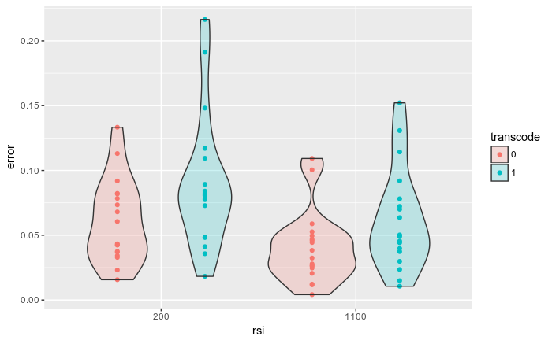

```r
error_data$transcode <- as.factor(error_data$transcode)
error_data$rsi <- as.factor(error_data$rsi)
error_data %>%
  group_by(subject, rsi, transcode) %>%
  summarize(error = mean(error)) %>%
  print() %>%
  ggplot(aes(x = rsi, y = error)) + geom_point(aes(group = transcode, color = transcode), position = position_dodge(width = 0.9)) +
    geom_violin(aes(fill = transcode),alpha = .2)
```

Checking that all subjects have data in all cells:

```r
error_data %>%
  group_by(subject, transcode, rsi) %>%
  summarize(error = mean(error)) %>%
  group_by(subject) %>%
  summarize(n())
```

| subject | n() |
| --- | --- |
| 1 | 4 |
| 2 | 4 |
| 3 | 4 |
| 4 | 4 |
| 5 | 4 |
| 6 | 4 |
| 7 | 4 |
| 8 | 4 |
| 9 | 4 |
| 10 | 4 |

[output cut: 8 more lines]

Looks good. Running the ANOVA and follow-ups if necessary:

```r
model1 <- error_data %>%
  group_by(subject, rsi, transcode) %>%
  summarize(error = mean(error)) %>%
  ezANOVA(wid = subject, within = .(rsi, transcode), dv = error, type = 2, detailed = T)
```

```
Converting "subject" to factor for ANOVA.
```

```r
cbind(model1$ANOVA, n2p = model1$ANOVA$SSn / (model1$ANOVA$SSn + model1$ANOVA$SSd))
```

|  | Effect | DFn | DFd | SSn | SSd | F | p | p<.05 | ges | n2p |
| --- | --- | --- | --- | --- | --- | --- | --- | --- | --- | --- |
| 1 | (Intercept) | 1 | 17 | 0.2892284056 | 0.076124732 | 64.5898219 | 3.428763e-07 | * | 0.738514027 | 0.79164068 |
| 2 | rsi | 1 | 17 | 0.0103093395 | 0.008359149 | 20.9661021 | 2.668055e-04 | * | 0.091462508 | 0.55223215 |
| 3 | transcode | 1 | 17 | 0.0116194315 | 0.010705780 | 18.4508119 | 4.897586e-04 | * | 0.101901012 | 0.52046232 |
| 4 | rsi:transcode | 1 | 17 | 0.0002859408 | 0.007217562 | 0.6734952 | 4.231947e-01 |  | 0.002784419 | 0.03810764 |

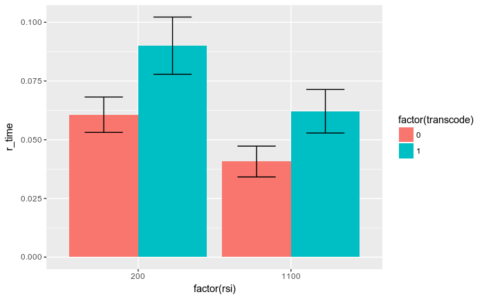

```r
dodge <- position_dodge(width = 0.9)
error_data %>%
  group_by(subject, rsi, transcode) %>%
  summarize(error = mean(error)) %>%
  group_by(rsi, transcode) %>%
  summarize(r_time = mean(error), se = sd(error) / sqrt(n())) %>%
  ggplot(aes(x = factor(rsi), y = r_time, group = factor(transcode))) + geom_bar(aes(fill = factor(transcode)), stat = 'identity', position = dodge) +
    geom_errorbar(aes(ymax = se + r_time, ymin = r_time - se, group = factor(transcode)), position = dodge, width = 0.5)
```

Two main effects, and no interaction. Below are the means for the main effects:

```r
error_data %>%
  group_by(subject, rsi, transcode) %>%
  summarize(error = mean(error)) %>%
  group_by(rsi) %>%
  summarize(errors = mean(error), se = sd(error) / sqrt(N))
```

| rsi | errors | se |
| --- | --- | --- |
| 200 | 0.07534630 | 0.010594570 |
| 1100 | 0.05141429 | 0.008318873 |

```r
error_data %>%
  group_by(subject, transcode, rsi) %>%
  summarize(error = mean(error)) %>%
  group_by(transcode) %>%
  summarize(errors = mean(error), se = sd(error) / sqrt(N))
```

| transcode | errors | se |
| --- | --- | --- |
| 0 | 0.05067671 | 0.007364893 |
| 1 | 0.07608387 | 0.011186036 |

Error rates are significantly higher when switching tasks and when RSI is short.